# In Class 2 - Dario Placencio

2023-02-22

Consider data set PropertyFund.txt. The variable of interest is the loss amount, i.e. Claim. Take a subset of the data that contain observations with positive losses. The goal is to forecast the amount of losses for a government entity.

```r
# Read the data
rm(list=ls())
dat <- read.table("PropertyFund.txt", header = TRUE, sep = "", dec = ".")
dat.loss <- dat[which(dat$Claim>0),]

# Preview dat.loss
head(dat.loss)
```

```
##    PolicyNum Year  Coverage Deduct Freq    Claim EntityType AlarmCredit
## 5     120002 2010  23.51149   1000    1  6838.87     County       AC00%
## 7     120003 2007 104.54682   5000    4 15500.00     County       AC15%
## 8     120003 2008 111.26501   5000    1  8775.00     County       AC15%
## 9     120003 2009 119.00522   5000    2 37470.91     County       AC15%
## 10    120003 2010 114.64608   5000    1  9711.28     County       AC15%
## 11    120004 2006  25.87963    500    3 13003.08     County       AC15%
```

```r
library("survival")
```

1. Perform Nelson Aalen estimation of the cumulative hazard function of loss amount. Plot the estimated cumulative hazard.

```r
# perform Nelson Aalen estimation of the cumulative hazard function
survObj <- Surv(dat.loss$Claim)
naEst <- survfit(survObj ~ 1, type = "fleming")
cumHazard <- -log(naEst$surv)
```

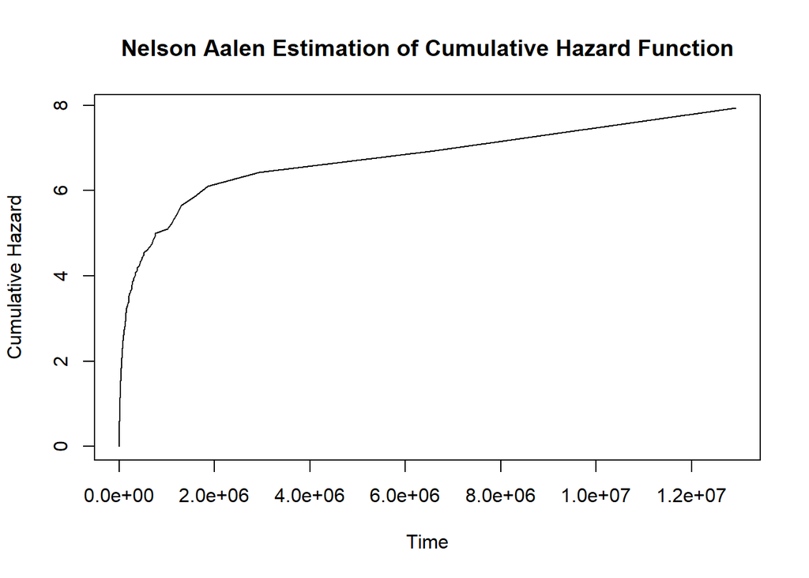

```r
# plot the estimated cumulative hazard function
plot(naEst$time, cumHazard, type = "l", xlab = "Time", ylab = "Cumulative Hazard", main = "Nelson Aalen Estimation of Cumulative Hazard Function")
```

2. Evaluate the cumulative hazard at 100,000, and from which, estimate the survival function at 100,000. (Hint: relation between S(t) and H(t)).

```r
# Evaluate the cumulative hazard at 100,000
time_points <- naEst$time
cumHazard_points <- -log(naEst$surv)
hazard_at_100000 <- approx(x = time_points, y = cumHazard_points, xout = 100000)$y
hazard_at_100000
```

```
## [1] 2.673439
```

To estimate the survival function at 100,000, we can use the relationship between the cumulative hazard and the survival function H(t) = -log(S(t)) Solving for S(t), we get S(t) = exp(-H(t))

Therefore, we can estimate the survival function at 100,000 by taking the exponential of the negative of the cumulative hazard estimate at 100,000.

```r
# estimate the survival function at 100,000
surv_at_100000 <- exp(-hazard_at_100000)
surv_at_100000
```

```
## [1] 0.06901448
```

3. Fit a Cox regression on the loss amount using entity type and logarithm of coverage as predictor. Report the estimated parameters. Plot the nonparametric estimates of the baseline cumulative hazard function.

```r
# fit a Cox regression on the loss amount using entity type and logarithm of coverage as predictors
cox_mod <- coxph(Surv(Claim) ~ EntityType + log(Coverage), data = dat.loss)

# report the estimated parameters
summary(cox_mod)
```

```
## Call:
## coxph(formula = Surv(Claim) ~ EntityType + log(Coverage), data = dat.loss)
##
##   n= 1566, number of events= 1566
##
##                         coef  exp(coef)   se(coef)       z Pr(>|z|)
## EntityTypeCounty   0.0133429  1.0134323  0.0844977   0.158  0.87453
## EntityTypeMisc    -0.1803062  0.8350145  0.1381775  -1.305  0.19193
## EntityTypeSchool  -0.0448247  0.9561651  0.0680665  -0.659  0.51019
## EntityTypeTown    -0.4311421  0.6497666  0.1624247  -2.654  0.00794 **
## EntityTypeVillage -0.0009538  0.9990466  0.0844141  -0.011  0.99098
## log(Coverage)     -0.3123433  0.7317303  0.0242067 -12.903  < 2e-16 ***
## ---
## Signif. codes:  0 '***' 0.001 '**' 0.01 '*' 0.05 '.' 0.1 ' ' 1
##
##                   exp(coef) exp(-coef) lower .95 upper .95
## EntityTypeCounty     1.0134     0.9867    0.8588    1.1960
## EntityTypeMisc       0.8350     1.1976    0.6369    1.0947
## EntityTypeSchool     0.9562     1.0458    0.8367    1.0926
## EntityTypeTown       0.6498     1.5390    0.4726    0.8933
## EntityTypeVillage    0.9990     1.0010    0.8467    1.1788
## log(Coverage)        0.7317     1.3666    0.6978    0.7673
##
## Concordance= 0.643  (se = 0.008 )
## Likelihood ratio test= 262  on 6 df,   p=<2e-16
## Wald test            = 273.2  on 6 df,   p=<2e-16
## Score (logrank) test = 277.2  on 6 df,   p=<2e-16
```

[figure not shown]

```r
# nonparametric estimates of the baseline cumulative hazard function
base_haz <- survfit(cox_mod, type = "fleming")

# plot the baseline cumulative hazard function
plot(base_haz, xlab = "Claim Amount", ylab = "Cumulative Hazard Function", main = "Nonparametric Estimate of Baseline Cumulative Hazard")
```

4. Consider the local government entity of the Madison School District. Assume that the logarithm of coverage amount (Coverage) is 500 (in thousand dollars). Use the cox regression in 3) to forecast the probability of an annual losses of greater than 100,000 dollars

```r
# create a new data frame with the covariate values for the Madison School District
newdat <- data.frame(EntityType = "School", Coverage = log(500))

# use the cox regression model to predict the risk of an annual loss greater than 100,000 dollars
risk_pred <- predict(cox_mod, newdata = newdat, type = "risk", times = 100000)

# forecast the probability of an annual loss greater than 100,000 dollars
1 - risk_pred
```

```
##          1
## -0.5061072
```